**Author: Nitesh Turaga, May 6th 2014**

# Goal: from Affymetrix raw data stored in CEL files to differential gene expression

### Some Basics

Getting the working directory, in my case

```r
getwd()
```

```
[1] "/Users/niteshturaga/Documents/GeneExpressionDataAnalysis/affyData"
```

Setting the working directory, in my case:

```r
setwd("~/Documents/GeneExpressionDataAnalysis/affyData/")
```

Check the date

```r
date()
```

```
[1] "Thu May  8 21:43:06 2014"
```

Clear the workspace, note the two “embedded” functions

```r
rm(list = ls())
```

Load the libraries needed for the analysis, note the use of “require”

```r
require(affy)
require(hgu95a.db)
```

### Load data previously saved, and check their classes

```r
load("./objs/affyData.rda")
```

Check the the workspace content

```r
ls()
```

```
## [1] "dat"     "dat.rma"
```

Check classes

```r
class(dat)
```

```
[1] "AffyBatch"
attr(,"package")
[1] "affy"
```

```r
### Note: dat.rma is an ExpresssionSet, which is a
class(dat.rma)
```

```
[1] "ExpressionSet"
attr(,"package")
[1] "Biobase"
```

## Access to data in the class

Slots/elements contained in the two classes can be seen using: Both **AffyBatch** and **ExpressionSet** are classes which **EXTENDS** the functionality of an **Biobase::eSet**. When a class X **EXTENDS** another base class Y, it means that, you have all the basic functionality of the parent class, and X also adds some functionality of its own. This is very popular in object oriented programming, called Inheritance.

**NOTE: SLOT NAMES USUALLY WORK AS ACCESSORS**

```r
slotNames(dat)
```

```
 [1] "cdfName"           "nrow"              "ncol"
 [4] "assayData"         "phenoData"         "featureData"
 [7] "experimentData"    "annotation"        "protocolData"
[10] ".__classVersion__"
```

```r
slotNames(dat.rma)
```

```
[1] "experimentData"    "assayData"         "phenoData"
[4] "featureData"       "annotation"        "protocolData"
[7] ".__classVersion__"
```

The **exprs** extracts normalized and summarized gene expression

```r
dat.expr <- exprs(dat.rma)
dim(dat.expr)
```

```
[1] 12626    13
```

The **pData** function extracts the phenotypic information

```r
pData(dat.rma)
```

```
                        Row.names sample   CellLine CancerType    CellType
GSM133995.CEL.gz GSM133995.CEL.gz      1       MCF7     breast  Epithelial
GSM134000.CEL.gz GSM134000.CEL.gz      2 MDA-MB-231     breast  Epithelial
GSM134015.CEL.gz GSM134015.CEL.gz      3      T-47D     breast  Epithelial
GSM134050.CEL.gz GSM134050.CEL.gz      4    COLO205      colon  Epithelial
GSM134060.CEL.gz GSM134060.CEL.gz      5    HCT-116      colon  Epithelial
GSM134070.CEL.gz GSM134070.CEL.gz      6       HT29      colon  Epithelial
GSM44082.CEL.gz   GSM44082.CEL.gz      7      Ramos    Burkitt Lymphocytes
GSM44083.CEL.gz   GSM44083.CEL.gz      8      P3HR1    Burkitt Lymphocytes
GSM44084.CEL.gz   GSM44084.CEL.gz      9      ST486    Burkitt Lymphocytes
GSM44088.CEL.gz   GSM44088.CEL.gz     10        Ly1      DLBCL Lymphocytes
GSM44089.CEL.gz   GSM44089.CEL.gz     11       Ly10      DLBCL Lymphocytes
GSM44091.CEL.gz   GSM44091.CEL.gz     12        Ly4      DLBCL Lymphocytes
GSM44092.CEL.gz   GSM44092.CEL.gz     13        Ly7      DLBCL Lymphocytes
                                                 Comment
GSM133995.CEL.gz                 Breast cancer cell line
GSM134000.CEL.gz                 Breast cancer cell line
GSM134015.CEL.gz                 Breast cancer cell line
GSM134050.CEL.gz                  Colon cancer cell line
GSM134060.CEL.gz                  Colon cancer cell line
GSM134070.CEL.gz                  Colon cancer cell line
GSM44082.CEL.gz               Burkitt lymphoma cell line
GSM44083.CEL.gz               Burkitt lymphoma cell line
GSM44084.CEL.gz               Burkitt lymphoma cell line
GSM44088.CEL.gz  Diffuse large B cell lymphoma cell line
GSM44089.CEL.gz  Diffuse large B cell lymphoma cell line
GSM44091.CEL.gz  Diffuse large B cell lymphoma cell line
GSM44092.CEL.gz  Diffuse large B cell lymphoma cell line
```

The **annotation** function extracts features information

```r
annotation(dat.rma)
```

```
[1] "hgu95a"
```

The **pm** function extracts perfect match probe intensities. *Perfect match probes are intended to match perfectly the target sequence*.

```r
dat.pm <- pm(dat)
```

```r
dim(dat.pm)
```

```
[1] 201807     13
```

The **mm** extract mismatch probe intensities *Mismatch probes having one base mismatch with the target sequence intended to account for non-specific binding*

```r
dat.mm <- mm(dat)
dim(dat.mm)
```

```
[1] 201807     13
```

## MA Plot

**MA-plots** are used to study dependences between the log ratio of two variables and the mean values of the same two variables. The log ratios of the two measurements are called M values (from “minus” in the log scale) and are represented in the vertical axis. The mean values of the two measurements are called A values (from “average” in the log scale) and are represented in the horizontal axis.

In microarray data contexts an MA-plot is used to compare two channels of intensity measurements. These two channels can be the red and green channels of one single chip of a two-color platform or the intensity measurements of two different arrays when using a single-channel platform. In a single-channel context at least two arrays are needed to draw a meaningful MA-plot.

\( M = log_{2}(R/G) = log_{2}(R) - log_{2}(G) \)

\( A = \frac{1}{2}log_{2}(R*G) = \frac{1}{2}(log_{2}(R) + log_{2}(G)) \)

### We can now make an MA-plot

We first define a function to divide the plotting area in rows and columns, if you are unfamiliar with how to set the plotting area, you can use the **?par**.

```r
mypar <- function(nRow = 1, nCol = 1, ptsExp = 1) {
    par(mar = c(2, 2, 2, 1))  # c(bottom, left, top, right)
    par(oma = c(2, 1, 1, 1))  #  c(bottom, left, top, right) giving the size of the outer margins in lines of text.
    par(mfrow = c(nRow, nCol))  # figures are drawn with (nr * nc) matrix
    par(cex = ptsExp)  # magnification of plotting text and points
}
```

We can compute rows and columns number based on the nuber of samples. You can do this also manually:

```r
nc <- ceiling(sqrt(ncol(dat.rma)))
nr <- ceiling(ncol(dat.rma)/nc)
```

### We can make a plot for the raw data, before normalization

```
Copyright M. P. Wand 1997-2009
```

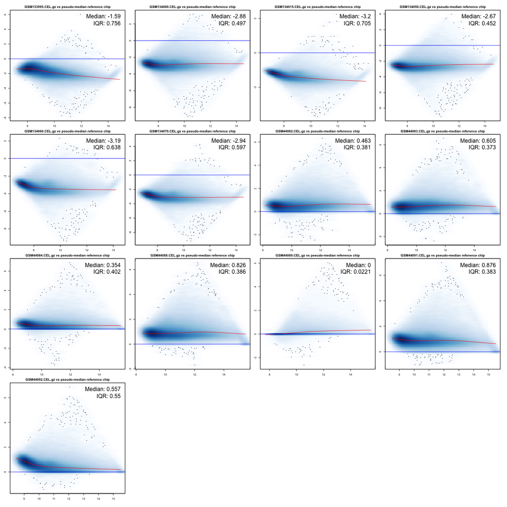

```r
mypar(nr, nc, 0.5)
MAplot(dat[, ], pairs = F, plot.method = "smoothScatter")
```

We can save the plot to a file,

```r
bitmap(file = "./figs/MApl.raw.png", width = 20, height = 10, res = 400)
mypar(nr, nc, 0.5)
par(oma = c(2, 1, 1, 1))
MAplot(dat[, ], pairs = F, plot.method = "smoothScatter")
dev.off()
```

### MA-plot after normalization

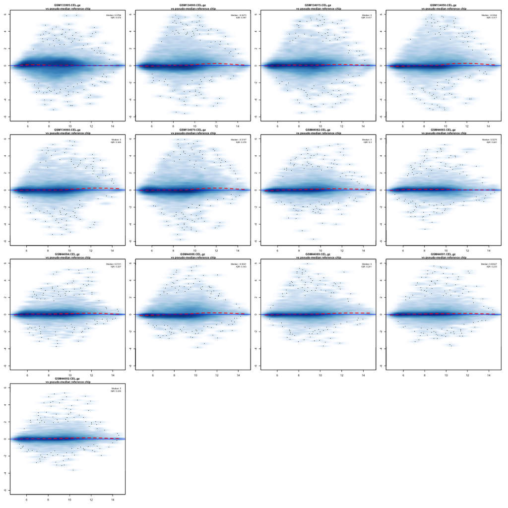

```r
mypar(nr, nc, 0.5)
par(oma = c(2, 1, 1, 1))  #overwrite initial mypar settings
a <- exprs(dat.rma)
for (i in 1:ncol(a)) {
    ma.plot(A = ((a[, i] + apply(a, 1, median))/2), M = (a[, i] - apply(a, 1,
        median)), show.statistics = TRUE, cex.main = 1, span = 1/3, family.loess = "gaussian",
        cex = 0.75, plot.method = "smoothScatter", add.loess = TRUE, lwd = 2,
        lty = 2, loess.col = "red", ylim = c(-6, 6), main = paste(colnames(a)[i],
            "\n vs pseudo-median reference chip"))
}
```

MA-plot after normalization: saved to a file

```r
bitmap(file = "./figs/MApl.rma.png", width = 20, height = 10, res = 400)
mypar(nr, nc, 0.5)
par(oma = c(2, 1, 1, 1))
a <- exprs(dat.rma)
for (i in 1:ncol(a)) {
    ma.plot(A = ((a[, i] + apply(a, 1, median))/2), M = (a[, i] - apply(a, 1,
        median)), show.statistics = TRUE, cex.main = 1, span = 1/3, family.loess = "gaussian",
        cex = 0.75, plot.method = "smoothScatter", add.loess = TRUE, lwd = 2,
        lty = 2, loess.col = "red", ylim = c(-6, 6), main = paste(colnames(a)[i],
            "vs pseudo-median reference chip"))
}
dev.off()
```

### Diagnostic Plots: 2D-Image

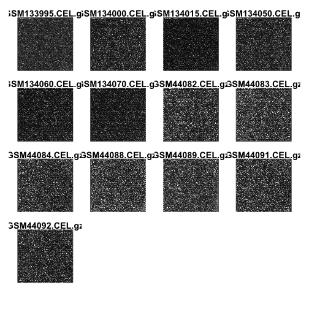

```r
bitmap(file = "./figs/ima2D.png", width = 2 * nr, height = 2 * nc, res = 144)
mypar(nr, nc, 1)
par(mar = c(1, 1, 1, 1))
image(dat[, ])
dev.off()
```

### Log2 intensities boxplots: before and after normalization

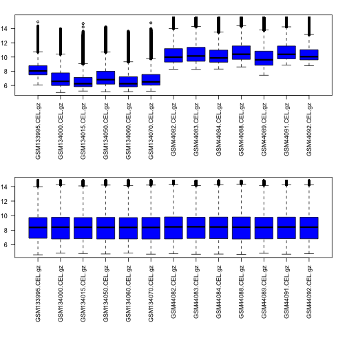

```r
bitmap(file = "./figs/exprBoxplot.png", width = 15, height = 15, res = 144)
mypar(2, 1, 0.75)
par(mar = c(10, 1, 1, 1))
### Before
boxplot(log2(exprs(dat)) ~ col(exprs(dat)), names = pData(dat.rma)[, "Row.names"],
    las = 2, col = "blue")
### After
boxplot(exprs(dat.rma) ~ col(exprs(dat.rma)), names = pData(dat.rma)[, "Row.names"],
    las = 2, col = "blue")
### Close the device
dev.off()
```

### RNA Degradation

The functions AffyRNAdeg, summaryAffyRNAdeg, and plotAffyRNAdeg aid in assessment of RNA quality. Since RNA degradation typically starts from the \( 5' \) end of the molecule, we would expect probe intensities to be systematically lowered at that end of a probeset when compared to the \( 3' \) end.

Compute RNA degradation

```r
deg <- AffyRNAdeg(dat)

names(deg)  # We plot the degradation and slope
```

```
[1] "N"               "sample.names"    "means.by.number" "ses"
[5] "slope"           "pvalue"
```

Make RNA degradation plot

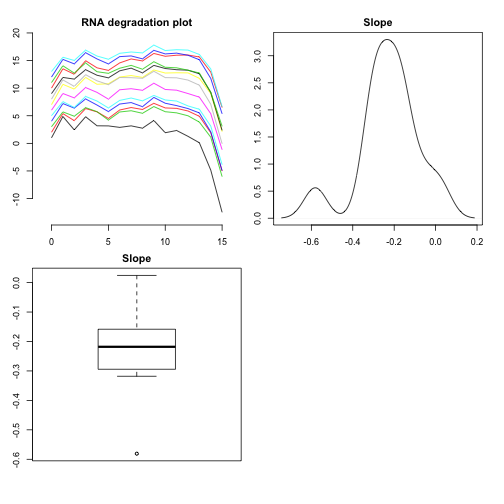

```r
bitmap(file = "./figs/degRNA.png", width = 5, height = 5, res = 1000)
mypar(2, 2, 0.75)
plotAffyRNAdeg(deg, cols = c(1:ncol(dat.rma)))
plot(density(deg$slope), main = "Slope")
boxplot(deg$slope, main = "Slope")
### Close the device
dev.off()
```

Find the scan date

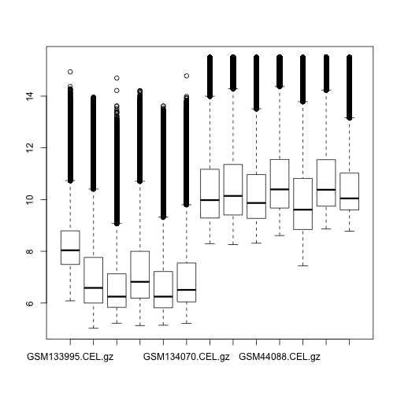

```r
dateOfScan <- protocolData(dat.rma)@data$ScanDate
# Don't need the time, so we will remove that using regular expressions
dateOfScan <- gsub(" .+", "", dateOfScan)
boxplot(log2(exprs(dat)), col = 1 + as.numeric(dateOfScan))
```